**CSE2215** - Computer Graphics

Elmar Eisemann, Martin Skrodzki, Michael Weinmann, Ricardo Marroqium

# CSE2215 - Computer Graphics 2024-2025 - Final Project

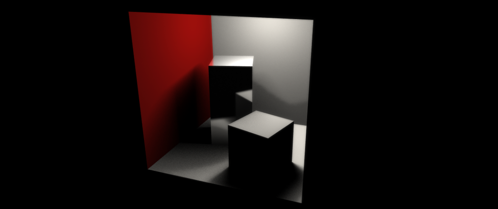

The final project targets a ray tracer. This document is quite detailed to provide a guideline through the tasks and clarify expectations, so please **read the entire document carefully** before you start.

**Sections:** General information - Framework information

**Appendices:** A: General Remarks - B: Standard Features - C: Extra Features

# General Information

- We strongly recommend to do the assignment **individually**.
- This practical will help you prepare for the programming exam.
- We highly recommend you to give the practical a try yourself to see whether you can solve it. Remember that the programming exam will also be an individual assessment.
- As always, you can approach the TAs with questions during the lab sessions.
- You should compile your code **on Windows with Visual Studio 2022** (using the default MSVC toolchain). Otherwise, the TAs might not be able to help you with related issues.
- Submission on Brightspace is not required for this practical.

## Testing

The final project is ungraded. We provide you with a unit test framework using the [Catch2](https://github.com/catchorg/Catch2/) under `tests` for you to evaluate your solutions.

To use the test framework, select and build the target `Bachelor_FinalProjectTests`. **We recommend using “DEBUG” profile to compile** tests because certain functionalities only work when c++ exception is enabled.

Once you have built and run the tests, a brief description of the testcase, captured variables (e.g. input, your output, and reference output), as well as the location of the testcase in the source file will be printed as a feedback for you to debug your solution.

In the beginning when you start with empty solutions, you may see a lot of test failures. We recommend that you run the testcases separately for a cleaner test output. This can be done via the following command:

```bash
Bachelor_FinalProjectTests.exe "Test_Name"
```

where `Test_Name` can be one of the results of `Bachelor_FinalProjectTests.exe --list-tests`. If you want to only run a specific section of a certain testcase, run

```bash
Bachelor_FinalProjectTests.exe "Test_Name" -c "Section_Name"
```

For example, `Bachelor_FinalProjectTests.exe "Interpolation" -c "computeBarycentricCoord"` will only test the `computeBarycentricCoord` section in `tests/src/interpolation.cpp`.

You may also create your own test cases by extending the source files under `tests/src`.

## Features

Features of the renderer are divided into standard and extra groups, based on their difficulty. We recommend implementing the standard features before working on extra ones.

Standard features and dependencies are described in Appendix B: Standard Features. Do not change method names/arguments and work with the given testing framework. You can create additional methods. It is a good idea to develop visual debugging components while working on a feature to verify its correctness and to facilitate the discussion with the teaching assistants. In some cases, such debugging tasks are indicated and part of the exercise.

Extra features will be described in Appendix C: Extra Features. Other ideas for extra features are welcome.

## (Optional) Image Competition

Submit your best image to a rendering competition! Feel free to send an image with the name `competion-XX.png` to the course email address.

By participating, your image might be featured in next year’s course.

Feel free to make your own custom scene. You can use any model you want (including downloaded), but do not forget to include references when you send it to us.

# Framework Information

In this project, you will build upon fundamentals that you learned in the lecture and implemented in the assignments to develop a fully functional ray tracer. We provide a framework to get you started, which we briefly present in the following.

The framework’s UI enables you to choose from a selection of test scenes to work with, including a custom scene (this initially loads a scene `custom.obj` from the data folder). If you like to load your own scene, you can simply overwrite the corresponding `custom.obj` with your own (please note that you should not rename your obj material file (`.mtl`), as the original filename is mentioned within the obj file itself).

## On BVHInterface, HitInfo, Features, RenderState, and Sampler

The framework is similar to the code you worked with during the *Ray Intersection Assignment*. However, there are some method arguments and structs, which you should familiarize yourself with. These are:

- `BVHInterface`, allows you to run intersection tests against the entire scene using an acceleration structure – the same that you develop in the assignments. For the project, we provide you with a running implementation in binary code that returns information about ray hits in a `HitInfo` object.
- `HitInfo`, defined in `common.h`, is returned by the various intersection tests, and stores information about a (potential) intersection point. This information is necessary for, e.g., shading, texture lookups, and other material interactions.
- `Features`/`ExtraFeatures`, defined in `common.h`, are booleans to enable/disable features of the renderer on the fly. Each *standard/extra* feature you implement has a corresponding Boolean here, and is accessible through the UI. Do not tamper with these Booleans, as the testing framework use them to isolate features. You are free to extend the `ExtraFeatures` object with your own parameters. A particular boolean is enableDebugDraw, which you should test for before executing any debug drawing calls within your code. This avoids drawing calls during the ray tracing process, when they would not serve any purpose.
- `RenderState`, defined in `render.h`, holds handles to `Scene`, `Features` and a `BVHInterface` object. A `RenderState` is created per render thread at the start of the rendering process, it is passed to most methods you implement and contains the global parameters influencing the rendering process. `RenderState` also holds a per-thread `Sampler` object, so you can generate random numbers in a thread-safe manner.
- `Sampler`, defined in `sampler.h` , is generated per render thread, and is a fast, well-distributed pseudo-random number generator, which is compatible with parallel execution, thus please use it instead of rand. This allows you to generate uniformly distributed 1D/2D random numbers.

## Code Structure

Most of the framework’s components are separated into header/source files such that you can work on them in isolation. Here is an overview of which files relate to which ray tracer components that you should implement:

- `shading.h/shading.cpp` - Your implementation of shading models.
- `recursive.h/recursive.cpp` - Your implementations of recursive ray-tracing features.
- `bvh.cpp` - Your implementation of the ray traversal through the BVH
- `interpolate.h/interpolate.cpp` - Your interpolation implementation of normals and other components.
- `texture.h/texture.cpp` - Your implementations of texture sampling features.
- `light.h/light.cpp` - Your implementations of light sampling features.
- `render.h/render.cpp` - Multi-threaded rendering code, and your implementation of multisampling.
- `extra.h/extra.cpp` - Your implementations of most optional *extra* features.

You do not have to touch the following files to solve the *standard* features, but you are encouraged to modify these to solve the *extra* features:

- `common.h` - Basic data structures used throughout the application
- `main.cpp` - The program launch point and the user interface.
- `draw.h/draw.cpp` - Helper methods for visual debugging.
- `scene.h/scene.cpp` - Responsible for loading the scene and auxiliary data.

The following files were not described, but **you must not modify these**, as they will probably break tests: `fwd.h`, `bvh_interface.h`, `sampler.h`, `config.h/config.cpp`, `screen.h/screen.cpp`, `verification.cpp`.

As a helpful tool, the file `verification.cpp` includes some assertions that tell you what component you may have modified.

## Compilation

As previously stated, we provide a prebuilt library for the required Windows environment with the reference solutions for the intersection functions as well as most BVH and some shading functions. We have also included binaries for Linux, but we cannot guarantee they will work with your compiler and OS version (you might need to use the solution without the prebuilt binaries in this case).

To start, you can compile the code and test the application. Note that you can compile the code in at least two different modes “DEBUG” or “RELEASE”. When compiled in “DEBUG” mode, there are a lot of additional tests behind the scenes, e.g., if you are accessing a `std::vector`, it always checks that you stay within its bounds. It is very useful to compile in “DEBUG” mode when developing code to ensure that all these tests are performed. Nevertheless, once the code is working, you should switch to “RELEASE”. If you now compile the code, it will be optimized and results in a significant speedup - especially useful when working with complex scenes. In the same spirit, when in “DEBUG” mode, you should rather work with simpler scenes to avoid long render times. Whichever mode you chose, once compiled, you can launch the application.

On our side, we use MSVC on Windows to compile your project and run tests. With this in mind, you **should not** use any external libraries (except for the included library `Provided.lib`).

## Rasterization Mode

From the menu, you can choose a *Rasterization* and a *Ray traced* view mode. The OpenGL-based *Rasterization* mode serves for debugging and scene control.

The GUI allows you to insert, remove and otherwise modify light sources, which are only used during *Ray traced* mode. This means the illumination in *Rasterization* mode does not correspond to the illumination in *Ray traced* mode. During Rasterization, we just consider a single light source in the scene to add some illumination.

Visual debugging features are only enabled during the *Rasterization* mode. See Visual Debugging for more information.

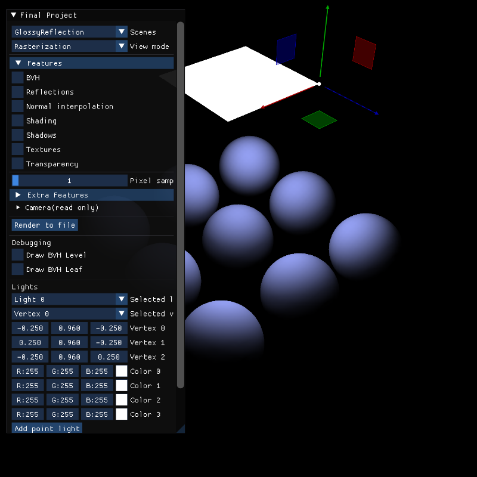

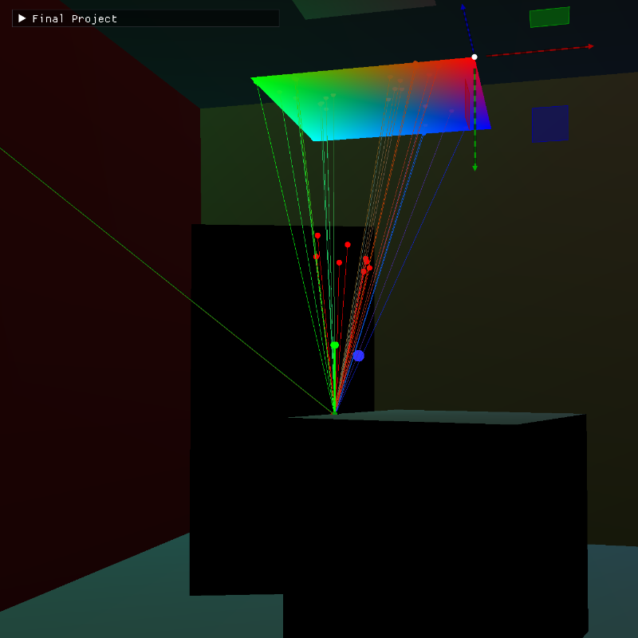

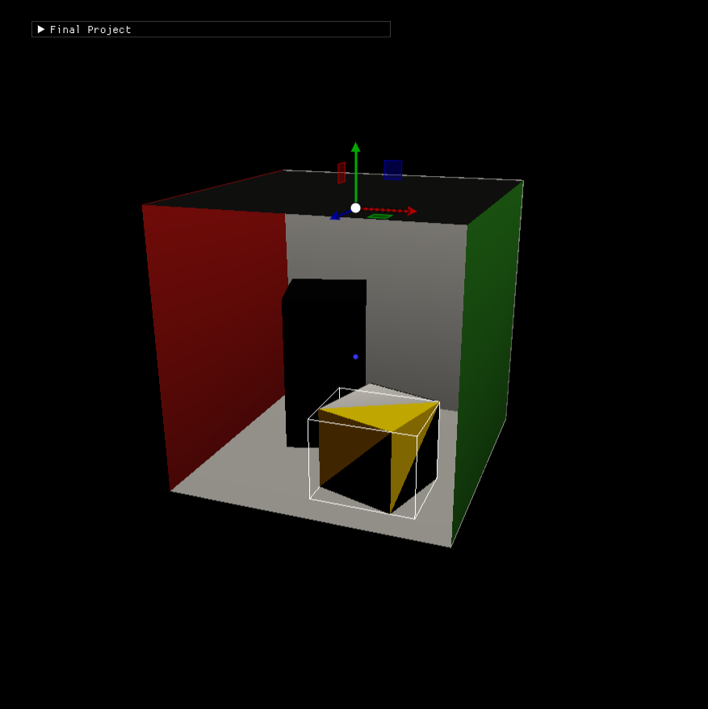

## Ray Traced Mode

During the *Ray traced* mode, the program generates at least one camera ray per pixel. This is bootstrapped by the `renderImage()` method in `render.h/render.cpp`. For each camera ray, the `renderRay()` method in `recursive.h/recursive.cpp` is called, which computes an RGB color value by determining the light along that ray. The `renderRay()` method calls other methods such that reflections, shadows, and other effects are considered. We recommend you read both methods to understand them, but you should not have to modify these in your implementation.

While the *Ray traced* mode traces actual rays for each pixel, you can also click the “Render to file” button to render an image and save it to file directly. This functionality is available in the *Rasterization* mode, so you can render to a file without switching to *Ray traced* mode, if the latter is too slow. For simple scenes, the *Ray traced* mode may be interactive, but as scene and effect complexity increases, ray tracing performance will inevitably slow down – hence, the need for the provided BVH data structure.

Rendering the Cornell Box without any features enabled should result in the following image. If you are using the prebuilt intersect library, you should be able to reproduce this result just by running the program before altering any code.

[figure not shown]

When a scene is loaded, it is centered and scaled according to the longest axis. Hereby, the placing of the light sources in the scene via the interface is facilitated. Via the interface, you can add light sources, change their type/color or move them around.

## Visual Debugging

For some features, you are expected to implement *Visual Debugging tools*. This is generally the element to start with, and it should aid in verifying the correctness of your implementation. By having visual feedback of calculations, you are able to catch bugs early on. Visual debugging can be implemented in the same methods as the rest of your code. You should make use of the `enableDebugDraw` variable in the features of the RenderState to test whether the debug drawing should be executed. This variable can be activated and deactivated in the UI. During ray tracing, your debug code will then be ignored, as the variable is set to false, so that it does not interfere with the image generation.

Below are some tips to help you:

- When you press `r` in *Rasterization* mode, a single debug ray is created through the mouse cursor position. By using `drawRay()` from `draw.h/draw.cpp` and other draw functions, you will illustrate the debug ray’s traversal through the scene. This allows you to inspect, e.g., reflections, transparency, or visibility tests.
- The UI library, [Dear ImGui](https://github.com/ocornut/imgui) allows you to inject your own interfaces and sliders throughout the code. Dear ImGui makes it simple, so we recommend you use it for visual debugging.
- Experiment with the debugging outputs. For example, you can color a ray to illustrate the current depth with respect to the number of reflections, or you can draw a line to illustrate the normal of each surfaces encountered by the ray.
- For other features you will need other forms of visual debugging that are not based on drawing rays. You might notice quickly that such visualizations are very useful. Refer to `draw.h/draw.cpp` for some helper code.

# Appendix A - General Remarks

## Materials (.MTL)

OBJ files have an optional accompanying MTL file. When you create a model with materials in Blender, the MTL file is also exported together with the OBJ file. Note that some advanced material options in Blender are not supported by the MTL file format. The MTL files are automatically loaded by the framework, since the MTL filename is mentioned in the OBJ file. We have added a Material structure to the framework to allow easy access to material coefficients.

```cpp
// Defined in framework/mesh.h

struct Material {

    glm::vec3 kd;

    glm::vec3 ks { 0.0f };

    float shininess { 1.0f };

    float transparency { 1.0f };



    // Pointer to optional diffuse texture

    std::shared_ptr<Image> kdTexture;

};
```

**Diffuse coefficient.** While you could directly use the kd value for diffuse shading, we suggest that you retrieve the coefficient via a helper method: `sampleMaterialKd()` in the `shading.h` file. In case that you have implemented the texture interpolation functions and the model uses a texture, `sampleMaterialKd()` will return the correct value.

```cpp
glm::vec3 kd = sampleMaterialKd(state, hitInfo);
```

**Transparency.** There is one additional parameter to the material, `transparency`, which ranges from 0.0 (fully transparent) to 1.0 (fully opaque). Note that, despite its name, this corresponds directly to the alpha component in alpha blending. This should be used for your implementation. In Blender you can set the transparency by going to the Material tab, activating transparency and setting the Alpha value. This value will be exported to the MTL file and imported by the framework.

**Multiple materials.** If you created a model that uses multiple materials, the mesh will be split into submeshes. The `loadMesh` method in `mesh.cpp` actually returns a vector of meshes, and not a single mesh, such that each submesh has its own material properties. Also note that the BVH structure represents the entire scene, and already loops over all submeshes for you. In the end, you can directly access the material object of a (sub)mesh through the `HitInfo` object.

## Drawing debug rays

A ray is defined by its origin, direction, and intersection parameter *t*, as defined in the Ray Intersection assignment. You can define your own rays for debugging and call the method `drawRay` from `draw.h/draw.cpp` to render it in Rasterization mode. This function also draws a small sphere at the intersection point, unless you do not modify the *t* value (it is set to infinity - i.e. FLOAT_MAX).

Here is an example of how to draw a green ray:

```cpp
// Define an arbitrary ray and the color green

if (state.features.enableDebugDraw)

{

Ray ray = { .origin = glm::vec3(1, 0, 2), .direction = glm:vec3(0, 0, 1), .t = 3.0 };

glm::vec3 color (0, 1, 0);



// Call drawRay, declared in the `draw.h` file

drawRay(ray, color);

}
```

NB: **please do the `if (state.features.enableDebugDraw)` check before using any debug drawing methods**. Otherwise, testing could fail due to invoking OpenGL calls in a non-OpenGL context.

## Drawing debug boxes

In the `draw.h/draw.cpp` file you can likewise find a method to draw axis-aligned bounding boxes (AABBs):

```cpp
void drawAABB(const AxisAlignedBox& box, DrawMode drawMode, const glm::vec3& color, float transparency);
```

The draw mode can be either `DrawMode::Filled` to render the sides of the AABB, or `DrawMode::Wireframe` to render only the edges. You can also pass a color and transparency value. This last value can be used with DrawMode::Filled to draw transparent boxes, where 0.0 if fully transparent and 1.0 is fully opaque.

# Appendix B - Standard Feature Descriptions

Be sure to read **all** feature descriptions carefully, including both programming and visual debug tasks.

```
The visual debug will help you assess the validity of your solutions to the programming tasks.

Therefore, it can be a good idea to start with the visual debug tasks and proceed in parallel.


The standard features also include several reflection tasks. You might be asked to investigate and discuss parameters or behavior of a given implementation.
```

In the following, we will present each of the standard features before tackling the extra features for the second part of the project.

## Shading models

**Flags:** `features.enableShading`, `features.shadingModel`, **files:** `shading.h`, `shading.cpp`.

This feature partially repeats work from prior assignments, and requires you to implement a custom shading model. Standard shading models are already provided via the library as binary. You must implement a non-photorealistic model which instead evaluates a piecewise linear function - a gradient function - to determine surface color.

### Methods

- `LinearGradient.sample(...)`, `computeLinearGradientModel(...)` - The idea is that a LinearGradient is used to color the object. Each entry in the LinearGradient is a boundary position and a corresponding color, referred to as a component. These components are used to encode the colors as bins.

For a number ti between [-1, 1], we determine the two components whose positions englobe ti and linearly interpolate their colors based on ti’s relative position between both. If ti is beyond the smallest/largest components, the nearest component color must be sampled.

In the latter function, given a camera direction, a light direction, a relevant intersection, and a color coming in from the light call the sampling function using the cosine of theta, as defined in the diffuse shading model.

### Visual debug tasks and reflection tasks

- Hard-code a LinearGradient and use it to illustrates the difference between the Blinn-Phong and the Phong model (both are provided via the library as a binary) and you can use the shading mode LinearGradientComparison. What colors are good choices for the LinearGradient definition? How many components in the LinearGradient would you minimally suggest?

## Recursive ray reflections

**Flags:** `features.enableReflections`, **files:** `recursive.h`, `recursive.cpp`.

This feature extends the method `renderRay(...)` to enable recursive specular reflections. Every time a ray intersects a specular surface (read, `material.ks` is non-zero), you should generate a mirror reflectance ray and evaluate its contribution.

### Methods

- `generateReflectionRay(...)` - Given an incident ray and an intersection point, generate a mirrored ray.
- `renderRaySpecularComponent(...)` - Given a camera ray (or secondary ray) and an intersection, compute the contribution of a mirrored ray, by recursively evaluating renderRay(…, depth + 1), and add the result times material.ks to the current intersection’s hit color.

### Example renders

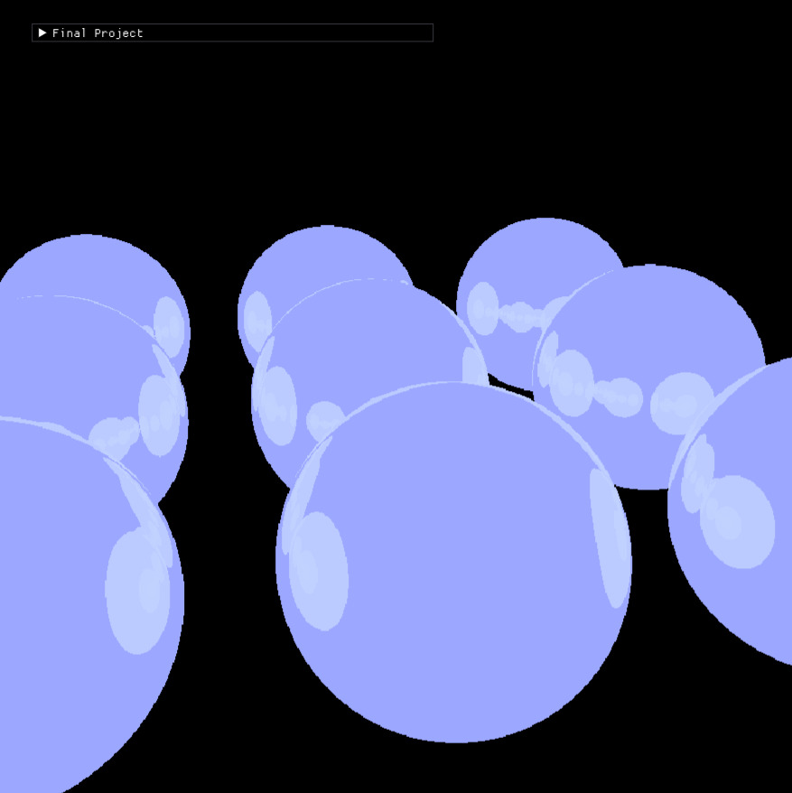

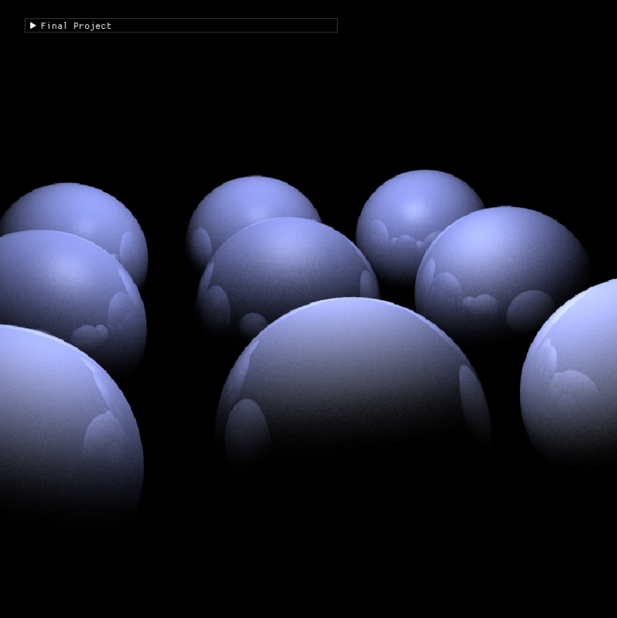

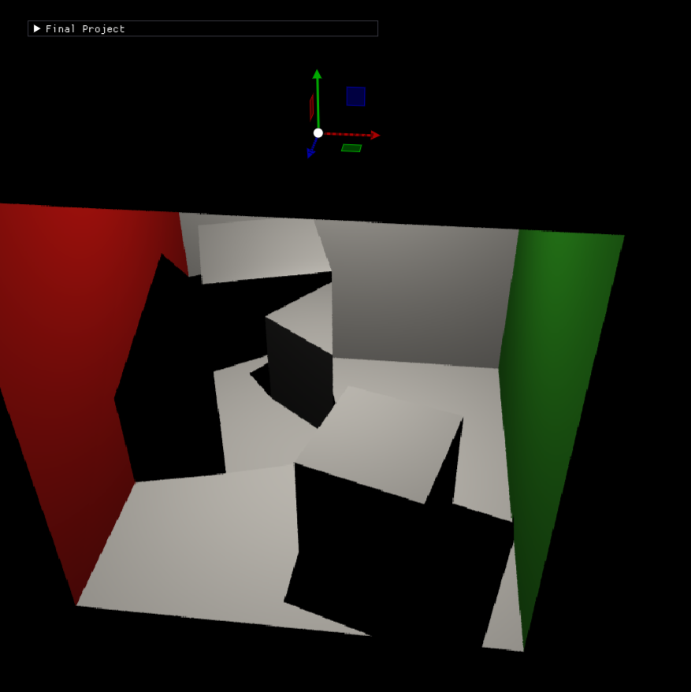

### Visual debug tasks and reflection tasks

- Visualize the surface normal at the location, where your ray reflects and the light direction vector. Also visualize secondary rays with different colors.

## Recursive ray transparency

**Flags:** `features.enableTransparency`, **files:** `recursive.h`, `recursive.cpp`.

This feature extends the method `renderRay(...)` to enable recursive transparent passthrough. Every time a ray intersects a transparent surface (read, `material.transparency` is smaller one), you should continue along the ray (passthrough ray), evaluate its contribution, and correctly **alpha-blend** the results.

### Methods

- `generatePassthroughRay(...)` - Given an incident ray and a intersection point, generate a passthrough ray for transparency, starting at the intersection point and continuing in the same direction.
- `renderRayTransparentComponent(...)` - Given a camera ray (or reflected camera ray) and an intersection, compute the contribution of a passthrough transparent ray, recursively evaluating renderRay(…, depth + 1) along this ray, and correctly alpha-blend the result with the current intersection’s hit color.

### Example renders

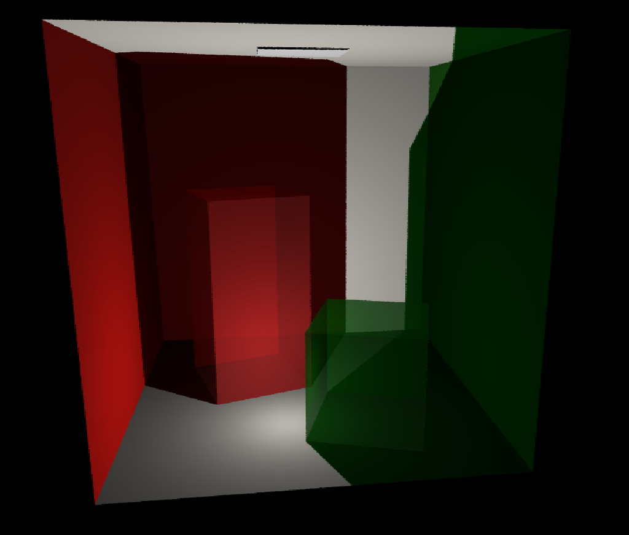

### Visual debug tasks and reflection tasks

- Visualize passthrough rays using the blended color, illustrate the intersection points, and show properties of the intersected surface (transparency, kd) in a suitable manner.

## Interpolation

**Flags:** `features.enableNormalInterp` **files:** `interpolate.h`, `interpolate.cpp`.

The project comes with a compiled library to build the hierarchy and to perform the ray traversal in to find the intersection point. Hereby, you have immediately a reasonably fast ray tracer.

### Methods

- `computeBarycentricCoord(...)`, `interpolateNormal(...)/interpolateTexCoord(...)`

The provided solution does **not** determine the barycentric coordinates of the intersection point yet. Compute the barycentric coordinates of an intersection point in form of a vec3 with the barycentric coordinates (alpha, beta, gamma) in interpolate.cpp. In the same file, add the code to interpolate normals and texture coordinates, based on the computed barycentric coordinates. Call these functions from within your traversal code to set all entries of the hitInfo object to the correct value.

To render your function more robust, in case that the provided vertex is not on the triangle, find the closest point within the triangle and determine its barycentric coordinates.

## Texture mapping

**Flags:** `features.enableTextureMapping`, **files:** `texture.h`, `texture.cpp`, **dependency:** ray traversal and barycentric coordinates.

Support textures in the ray-tracer to give your rendered image a detailed look. Given texture coordinate data on the `hitInfo` object, you can perform texture lookups in a diffuse texture.

### Methods

- `sampleTextureNearest(...)` - Given an image and relevant texture coordinates, sample the texture s.t. the nearest texel to the coordinates is acquired from the image.
- `sampleTextureBilinear(...)` - Given an image and relevant texture coordinates, sample the texture s.t. a bilinearly interpolated texel is acquired from the image.

### Example renders

[figure not shown]

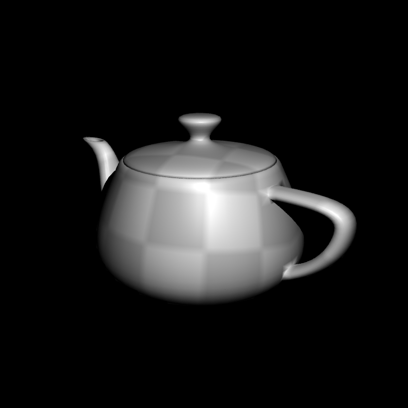

### Visual debug tasks and reflection tasks

- Implement a view of the texture space and how the geometry is mapped into it. Highlight the ray intersection position as well as the involved pixels from texture space.

Think about and show illustration for secondary hitpoints over several objects.

## Lights and shadows

**Flags:** `features.enableShadows`, `features.numShadowSamples`, **files:** `light.h`, `light.cpp`, **dependency:** shading models.

In this feature, you will implement the contribution of lights and shadows. By default, the only light type that is supported is the point light as `computeContributionPointLight(...)` in `light.cpp` has a barebones implementation (which does not incorporate shadows). You will implement the following methods, and in doing so build towards a good setup for handling the three different light types (points, segments, and parallelograms) with both hard and soft shadows. We recommend that you implement them in the order given in this document.

### Methods

- `sampleSegmentLight(...)` - Given a single segment light, transform a uniformly distributed 1d sample in $[0, 1)$, into a uniformly sampled position and color on the segment light, and write these into the reference return values.
- `sampleParallelogramLight(...)` - Given a single parallelogram light, transform a uniformly distributed 2d sample in $[0, 1),$ into a uniformly sampled position and color on the paralellogram light, and write these into the reference return values.
- `visibilityOfLightSampleBinary(...)` - Given a sampled position on some light, and the emitted color at this position, return whether or not the light is visible from the provided ray/intersection.
- `computeContributionPointLight(...)` - Given a single point light, compute its contribution towards an incident ray at an intersection point.
- `computeContributionSegmentLight(...)/computeContributionParallelogramLight(...)` - Given a single segment/parallelogram light, compute its contribution towards an incident ray at an intersection point by integrating over the segment/parallelogram, taking `numSamples` samples.
- `testVisibilityLightSampleTransparency(...)` - Given a sampled position on some light, and the emitted color at this position, return the light that is visible from the provided ray/intersection taking alpha-blending into account. Use the following blending operation: lightColor = lightColor * kd * (1 - transparency). (as another reminder: transparency is the same as alpha in the lectures).

### Example renders

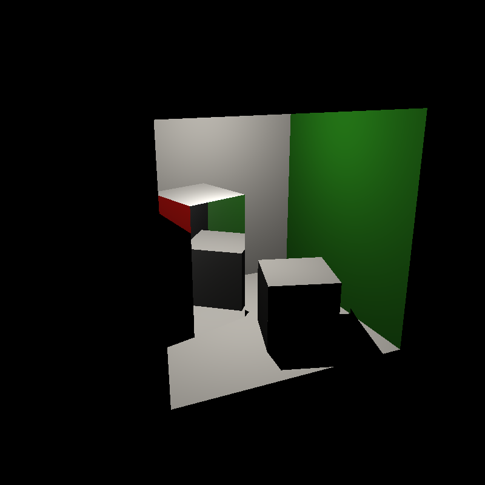

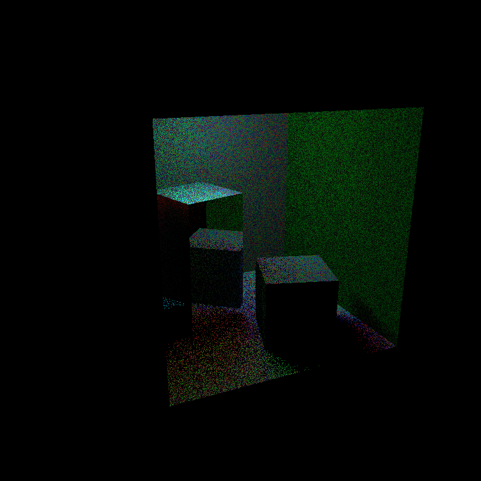

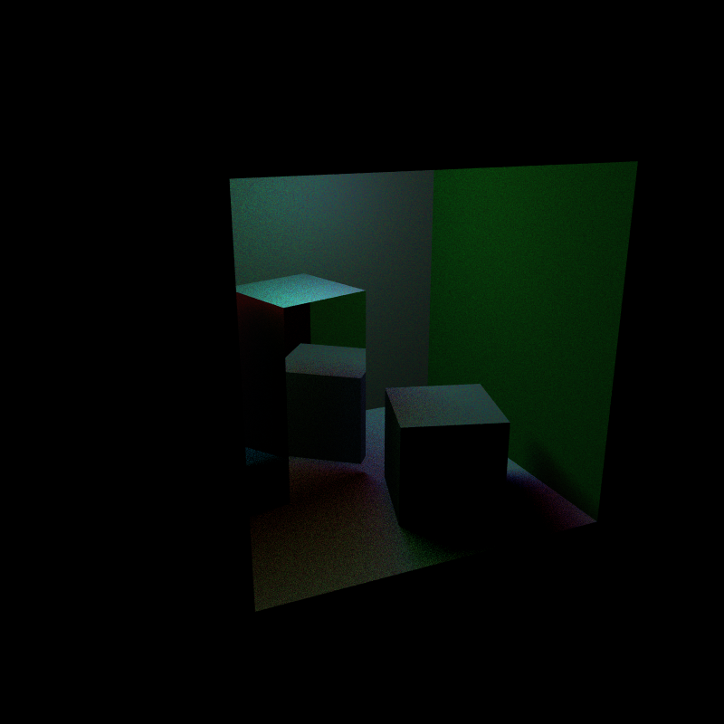

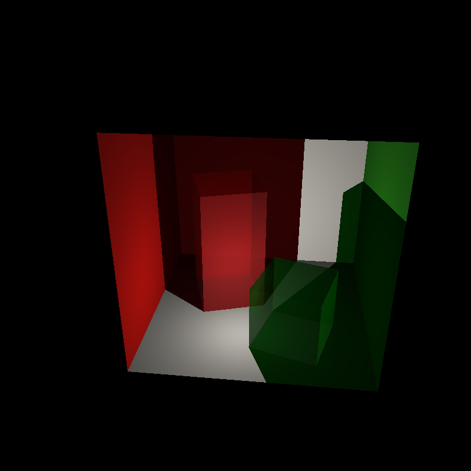

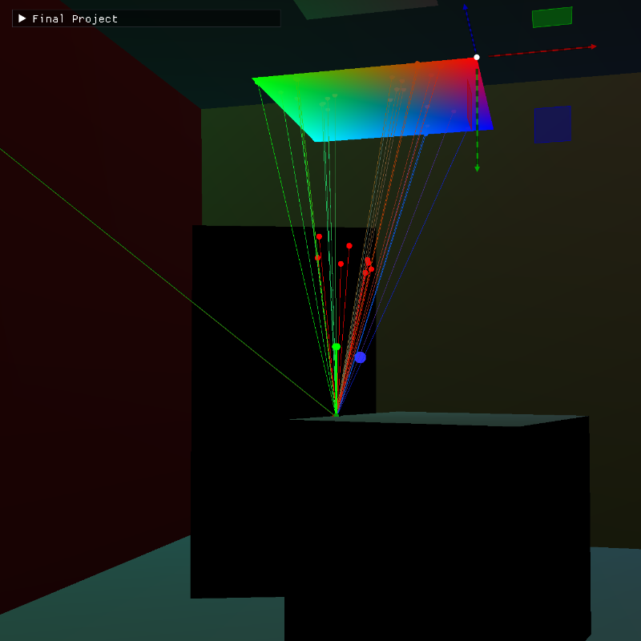

### Visual debug tasks and reflection tasks

- Visualize visibility rays and whether or not these pass/fail, as well as a visualization of the transparency.
- Visualize the samples generated on your segment/parallelogram light, to verify they are uniformly distributed across the light.
- Compare samples drawn with the provided sampler for 2D to the samples that you obtain by choosing both coordinates of a sample with the 1D random sampling. What do you observe?
- Reflect on why the blending operation used in the function `testVisibilityLightSampleTransparency(...)` (see above) is incorrect, based on the alpha blending derivation in the course. What would you propose how this could be modified?

## Multisampling

**Flags:** `features.numPixelSamples`, **files:** `render.h`, `render.cpp`.

To ensure that the image you render avoids aliasing, you must handle multisampling. While the ray-tracer by default renders pixels by sending a ray through the pixel’s center, you must now extend `generatePixelRays()` to support placement of multiple rays within a pixel. In addition, you must implement *stratified* sampling, where rays are randomly sampled from each cell in a grid across the pixel.

### Methods

- `generatePixelRaysUniform(...)` - Given a render state, camera, pixel position, and output resolution, generates a set of camera ray samples distributed uniformly across this pixel.
- `generatePixelRaysStratified(...)` - Given a render state, camera, pixel position, and output resolution, generates a set of camera ray samples placed using stratified sampling throughout this pixel.

### Example renders

[figure not shown]

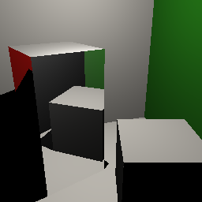

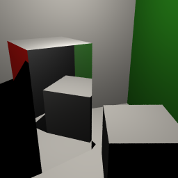

### Visual debug tasks and reflection tasks

- Provide visualizations of the sample distribution within a pixel for the different approaches by drawing the grid over a pixel plus the respectively sampled positions. As a guidance, you can find an exemplary depiction in the Physically-based Rendering book (see Figure 8.24 on https://pbr-book.org/4ed/Sampling_and_Reconstruction/Stratified_Sampler). Discuss and explain the differences.
- Provide visualizations of a scene for the different multisampling strategies and discuss the differences. Choose/make scenes and select settings to well illustrate the effects. What is the benefit of using jittering over using an unjittered sampling pattern?

# Appendix C - Extra Feature Descriptions

In this appendix, we provide descriptions of the *extra* features. Contrary to the *standard* features, there is more flexibility in deciding how or where to implement your solution. We only provide suggestions/guidelines. These features can be implemented with the material from the lectures and the book (Fundamentals of Computer Graphics 4th Edition), but you could also follow other resources.

We have made isolated placeholder methods available in `extra.h/extra.cpp`, within which you *should* be able to implement the *extra* features. If you use the placeholder methods, placeholder feature flags are available in the `ExtraFeatures` struct in `common.h`. These are integrated into the UI and currently correctly toggle their respective placeholder methods. You can decide to restructure the interface to your liking.

As discussed in the first part of the final-project instructions, you should think about an appropriate **visual debugging** process and use it to verify the correctness of your implementation. In that sense, you could reflect on explaining how and why your visual debugger helps to verify the correctness of the result.

## Environment maps

Given a camera ray (or reflected camera ray) that does not intersect the scene, retrieve its contribution from an environment map. You may have to add support for environment maps to the Scene object, and provide or hardcode the needed elements. Assume the environment map is given as a cube map, where each side of the cube has a separate texture. In its original definition, a cube map is always at an infinite distance from the scene. Here, we make the size of this cube a parameter, where only the highest setting refers to an infinite size.

**Flags:** `features.extra.enableEnvironmentMap`, **methods:** `sampleEnvironmentMap(...)`, **files:** `extra.h`, `extra.cpp`.

**Source.** Refer to *Lecture Textures* and the book.

For visual debugging, use an empty scene that only contains a highly-reflective sphere at its origin inside a simple cube room with textured walls. Set the cube map size to the size of the room. Show the view ray towards and the reflection ray off the sphere. Illustrate the intersection of the reflection ray with the cube map and change its color to the color stored in the cube map’s corresponding location. Compare the result for several sizes of the cube map - including infinity. How does the reflected image in the sphere change? Create two simple scenes that illustrate when a finite setting for the cube map performs better and when an infinite size is more suitable. Can you propose a different geometric shape instead of a cube map, with a suitable application case, to encode the environment map? Implement it with suitable debug options and show in how far it improved the result.

## Motion blur

Given the same input as for `renderImage()`, you are asked to produce an image with motion blur. The goal is to sample rays using different time steps, hereby motion in the camera view is resulting in blur. Here are some points to account for:

- Your approach should involve ray-tracing and not follow 2D or screen-space approaches!
- Your approach should involve a sampling-based approach (where the time domain is sampled between keyframes of motion), as opposed to simply averaging several frames.
- Your approach should move one or more objects along a B-spline (see Section “15.6.2 B-Splines” in the book) in 3D space. Additionally, you can move the camera.
- You should add several methods to visually debug your results and show the intermediate steps.

**Flags:** `features.extra.enableMotionBlur`, **methods:** `renderImageWithMotionBlur(...)`, **files:** `extra.h`, `extra.cpp`.

**Source.** Refer to *Lecture Ray Tracing* and the book.

To get insights on the feature and the correctness of your implementation, implement the following: - Render the spline that is used to animate the object during the Rasterization mode. - Enable the modifiction of the spline via the interface or interaction in the scene. - Render the scene at discrete time slices within the exposure time (e.g., t=0.0, t=0.25, t=0.5, t=1.0). Verify that object positions match their expected locations at those time stamps.

Advanced: If we assume a single moving object, can you adjust the sampling of the time domain such that the time samples are drawn roughly in accordance to the distance that the object moves on the screen? Implement a solution and explain why you chose it and why it improves the resulting image quality?

Can you propose and implement a modification of the acceleration structure to accomodate for motion in the scene?

Verify the correctness of your solutions via visual debugging.

## Bloom filter post-processing

Given a rendered image, compute and apply a bloom post-processing effect to add a glow to bright pixels, i.e., threshold the image to determine bright pixels, blur the resulting image and add it back to the original.

- As a filter, we want to use a 2D Gaussian filter. To accelerate its application, we will use the fact that it is a separable filter, meaning that we can first filter the image horizontally, then the result vertically.
- To define the filter’s values, apply the following: First, the $k^{th}$ value in a 1D filter is defined as $C(n,k)=\frac{n!}{k!(n-k)!}$, where $n+1$ is the total number of pixels and k the entry in the 1D filter. Then, you should normalize the filter by dividing each filter pixel by the total sum of all filter pixel values.
- Make the filter size and threshold parameters in the interface.
- Enable the use of a grayscale image as a bloom filter. Make sure to normalize the filter.
- Design an alternative to the binary thresholding and rather map a user-defined range of brightness values to values between 0,1 in the threshold mask. Experiment with different mapping functions and motivate your choices by explaining their effect.

**Flags:** `features.extra.enableBloomEffect`, **methods:** `postprocessImageWithBloom(...)`, **files:** `extra.h`, `extra.cpp`.

**Source.** Refer to *Lecture Images*.

To verify your implementation: - Render only the Bloom contribution without adding it back to the base image to discover errors. - Visualize the brightness mask. For this purpose, render the thresholded mask that extracts bright pixels and verify that only areas above the luminance threshold contribute to the mask.

## Glossy reflections

Given a camera ray (or reflected camera ray) and an intersection, evaluate the contribution of a set of reflection rays to approximate a glossy material (like an imperfect mirror or brushed metal). Do so by recursively evaluating `renderRay(..., depth + 1)` along each ray, and adding the results times material.ks to the current intersection’s hit color. Here are some points to account for:

- The book explains that you should construct an orthonormal basis along the ray, and sample on the quad formed by this basis. We expect you to instead sample on a disk, orthogonal to the ray. Sample the disk uniformly.
- You should use the material shininess parameter to modulate how glossy the surface looks.

A higher shininess value should result in a smaller disc size.

**Flags:** `features.extra.enableGlossyReflection`, `features.extra.numGlossySamples`, **methods:** `renderRayGlossyComponent(...)`, **files:** `extra.h`, `extra.cpp`.

**Source.** Refer to the book.

To verify the correctness of your implementation: - Check whether the orthogonal basis created along the ray is correctly defined. - Visualize the samples on the disk. Are the samples well (uniformly) distributed? - Render the reflection ray bundle by drawing lines representing the secondary rays originating from a reflective surface point. - Evaluate whether the bundle is centered around the perfect reflection direction. - Check the spread of the bundle (i.e., narrower for higher shininess, wider for lower shininess) and explain your choice for how to reduce the size of your disk.

## Depth of Field

Given the same input as for `renderImage()`, produce an image exhibiting depth of field. Here, you generate camera rays according to a thin lens camera model (using paraxial ray approximation), which can simulate objects to be in and out of focus.

Some points to account for: - 2D or screen-space approaches are not accepted, you should define/evaluate rays. - Add suitable parameters to the interface (lens radius, distance to the image plane, and the focal length of the lens) to control the depth-of-field effect. -Each pixel center in your image corresponds to one point on a grid located on the focal plane, which can be found as the intersection between two rays. First, a ray from the pixel center through the lens center and, second, a ray from the pixel location that leaves orthogonally to the lens plane and is redirected at the lens plane through the lens’ focus. The resulting position is a location on the focal plane and all light rays reaching the pixel center can be matched with rays leaving a lens location through this point.

**Flags:** `features.extra.enableDepthOfField`, **methods:** `renderImageWithDepthOfField(...)`, **files:** `extra.h`, `extra.cpp`.

**Source.** Refer to the book and/or the nice video series of Prof. Anderson https://www.youtube.com/watch?v=hszHFJ-StJc.

To verify the correctness of your implementation: - Verify that all determined points on the focal plane actually lie in a plane and form a grid. - Draw focal plane, image plane, lens and rays. - For a plane at a distance different from the focal plane, the intersection of the rays towards the focal plane will form a cirle. Compute the size of this circle for an example by hand. Illustrate that your method works correctly by showing that when you place a flat object on this plane, that the out of focus effect is indeed identical to filtering the image with a circle of your computed radius. Show this for at least two different distances.